# 08 Gráficas

2024-02-08

## Análisis de datos I (MAT1409)

## 3 Representación Gráfica y Tabular

## Tema. 3.2.1 Gráfica de Serie de Tiempo: Características.

- Se usa para visualizar el cambio de una variable en el tiempo.
- La variable se dibuja en el eje vertical y el tiempo en el eje horizontal.
- Es compatible con escalas (log, normalización z, ect. )
- El orden es muy importante para este gráfico.

## Tema. 3.2.2 Gráfica de Serie de Tiempo: Usos.

- Tendencia: Se refiere al aumento o disminución del valor de la variable a lo largo del tiempo.
- Estacionalidad: Se refiere a un patrón que se repite regularmente de altibajos relacionados con el tiempo del calendario, como estaciones, trimestres, meses, días de la semana.
- Valores atípicos: estos son puntos de datos que están lejos de sus otros datos.
- Varianza (volatilidad): Se refiere a si la varianza es constante en el tiempo o no.
- Es popular en el análisis financiero y económico.

## Tema. 3.1.3 Tendencia Positiva

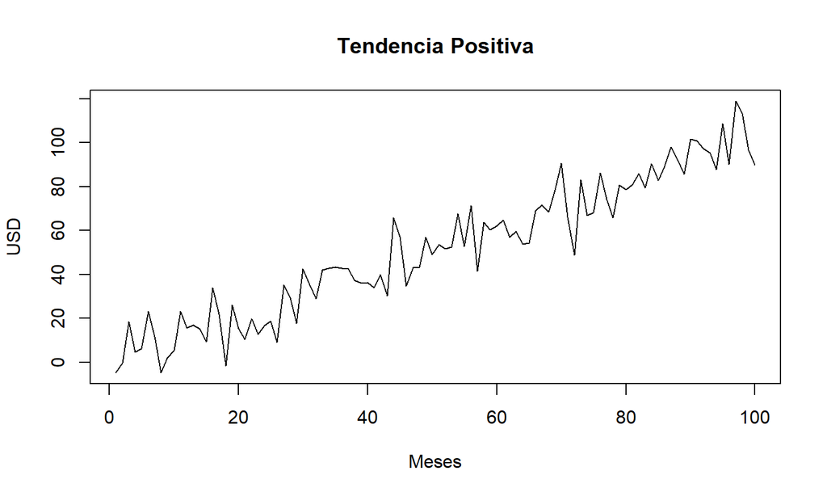

## Tema. 3.1.2 Tendencia Negativa

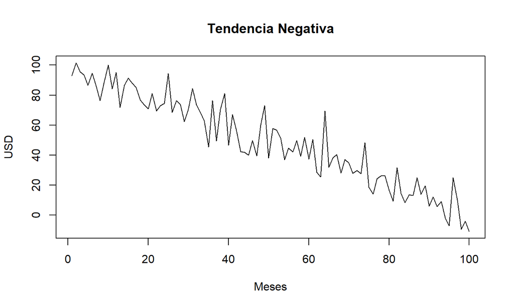

## Tema. 3.1.2 Tendencia estacionalidad

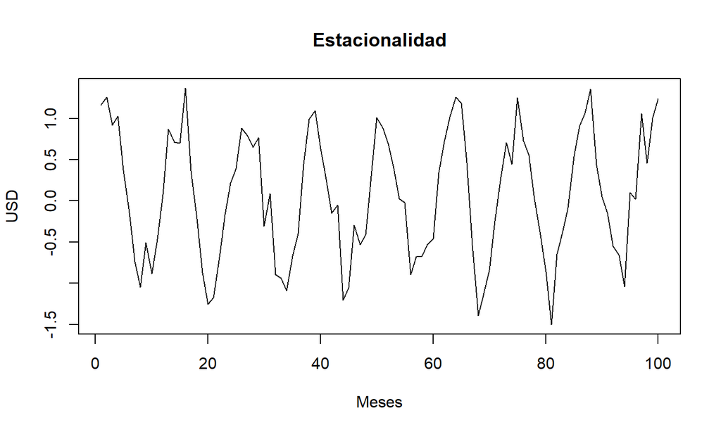

## Tema. 3.1.3 Alta Volatilidad

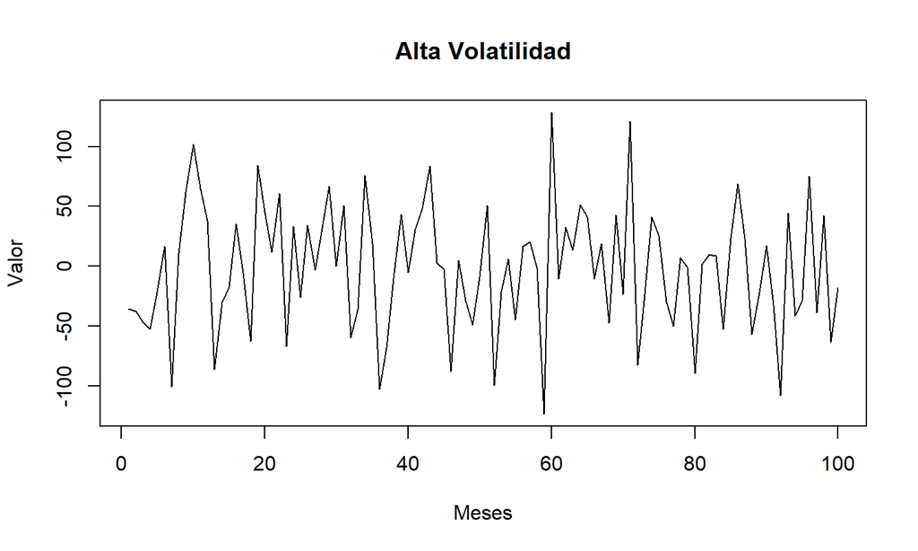

## Tema. 3.1.3 Baja Volatilidad

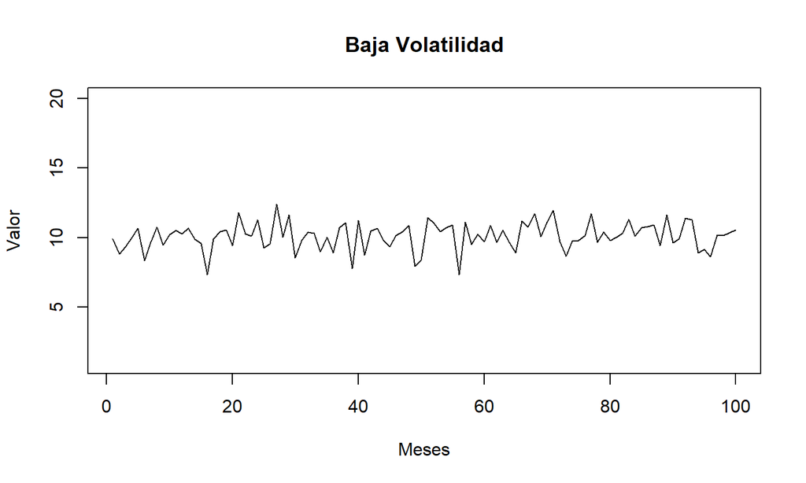

## Tema. 3.3.2 Gráfica de Dispersión: Usos.

- Se utiliza principalmente para visualizar la relación entre dos variables (positivo, negativo, no-relación).
- Correlación: Se puede usar para identificar si existe una correlación entre las dos variables.
- Valores atípicos: estos son puntos de datos que están lejos de la línea de tendencia.

## Tema. 3.3.3 Gráfica de Dispersión: Desempleo y PIB

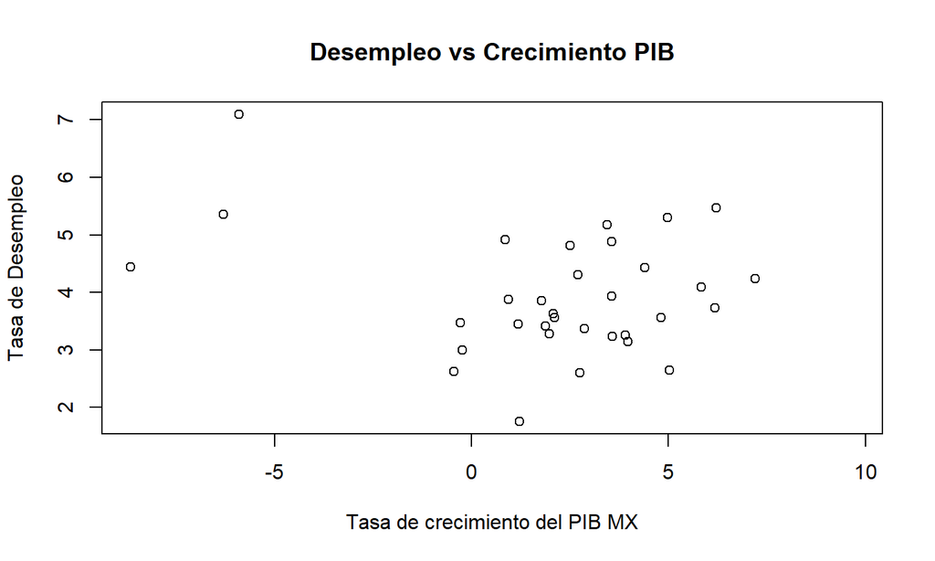

## Tema. 3.3.3 Gráfica de Dispersión: Desempleo y PIB, R. Negativo

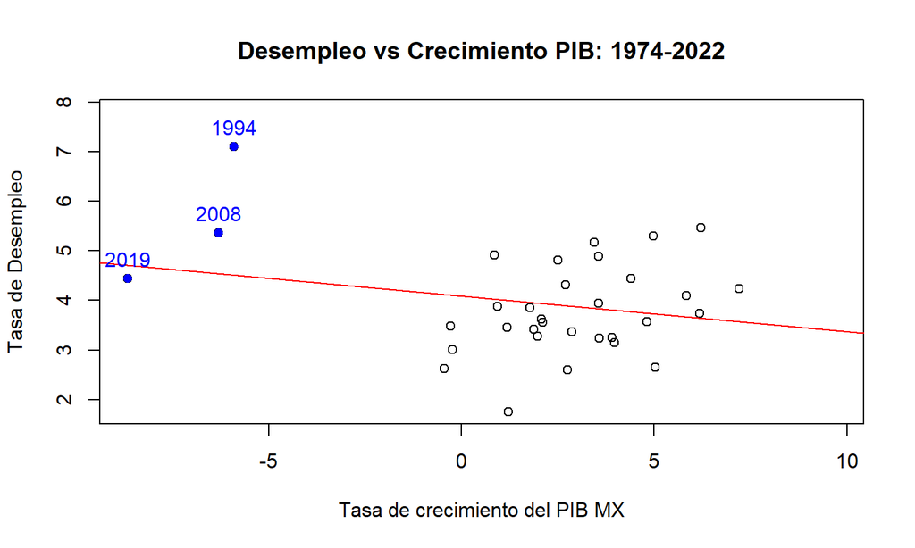

## Tema. 3.3.3 Gráfica de Dispersión: Desempleo y PIB, R. Positiva

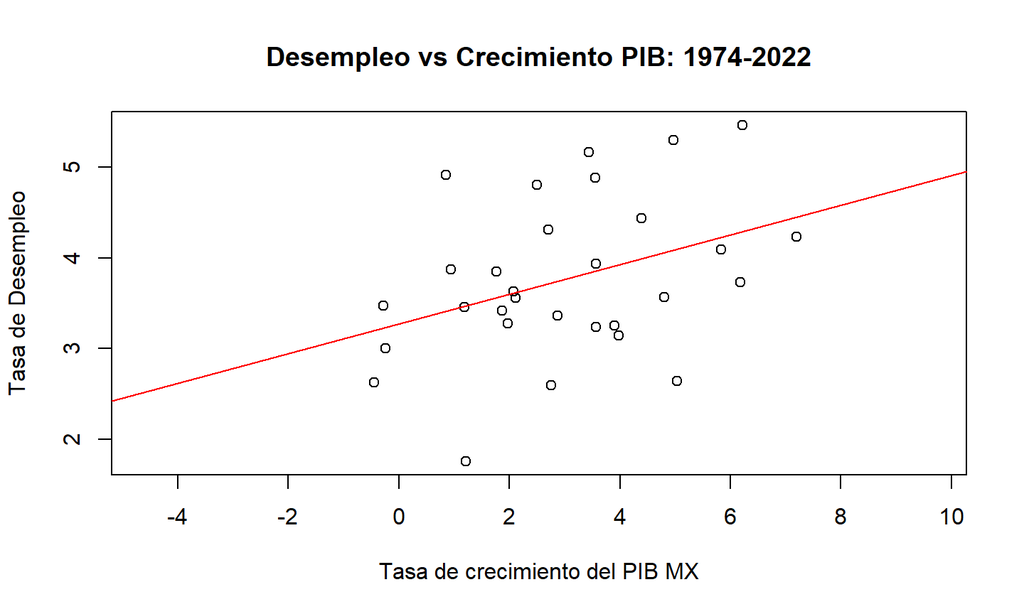

## Tema 3.4.1 Diagrama de Caja: Características.

- Representa la distribución de datos a través de cuartiles.
- La caja abarca el rango intercuartil (IQR), el 50% central de los datos.
- Bigotes: Se extienden desde la caja hasta los valores extremos dentro de \(1.5*IQR\).
- Cuartiles: Extremos de la caja representan el primer y tercer cuartil.
- Valores atípicos: Puntos individuales están fuera de los bigotes.

## Tema 3.4.2 Diagrama de Caja: Usos.

- Visualizar la mediana y los cuartiles.
- Útil para visualizar la dispersión.
- Visualizar valores atípicos (extremos).

## Tema 3.4.3 Diagrama de Caja: Sin valores extremos

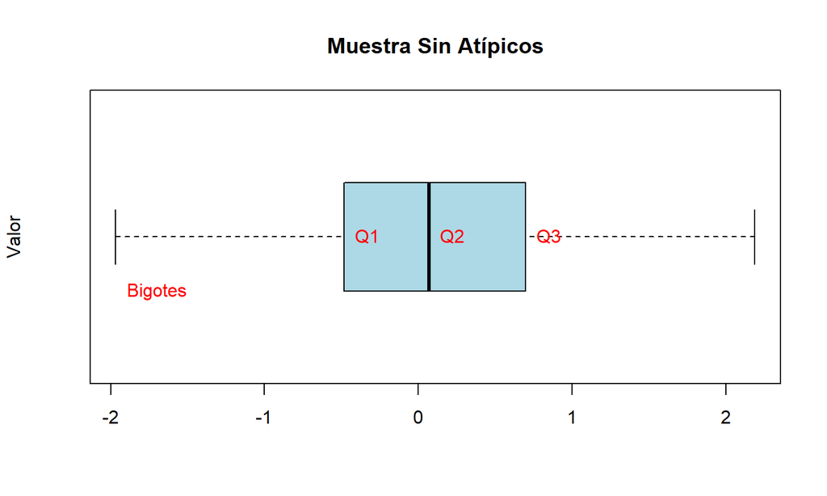

## Tema 3.4.3 Diagrama de Caja: Con valores extremos

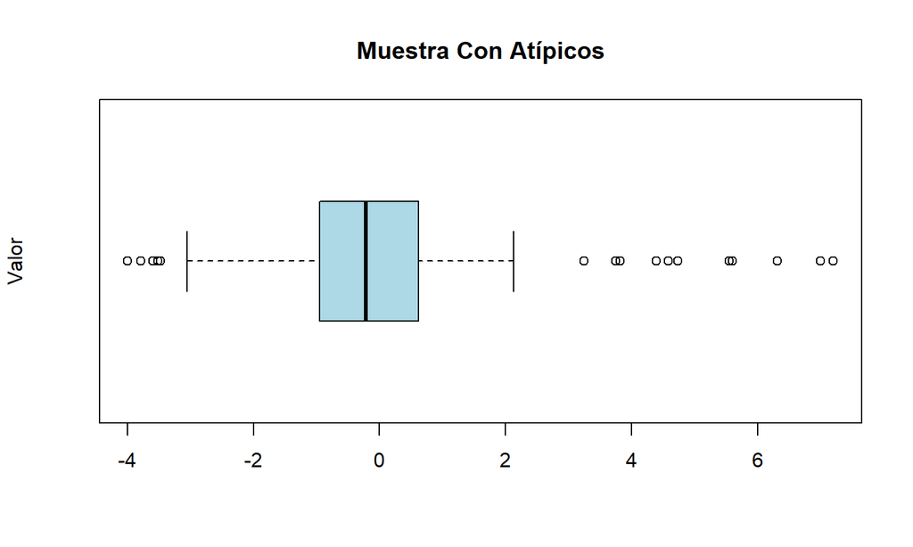

## Ejercicio 1:

El gasto en publicidad (miles dp) de una pequeña empresa está representado en la siguiente tabla.

- ¿Cuántas unidades vendió en promedio? (aritmética, geométrica y armónica.)

| Gasto | Frecuencia | Gasto.1 | Frecuencia.1 |
| --- | --- | --- | --- |
| 10.5 | 4 | 10.4 | 15 |
| 20.5 | 3 | 17.6 | 24 |
| 22.5 | 1 | 16.4 | 21 |
| 14.7 | 5 | 8.7 | 10 |
| 22.5 | 2 | 9.4 | 12 |

## Ejercicio 1: Respuestas

```
## [1] 2.520619
```

```
## [1] 13.50097
```

```
## [1] 12.91058
```

## Ejercicio 2: Media Geométrica Crecimiento Acumulado PIB

- Calcula el promedio del crecimiento acumulado del PIB en US con la media geométrica.

  | Año | PIB | Año.1 | PIB.1 |
  | --- | --- | --- | --- |
  | 2011 | 1.84 | 2016 | 2.95 |
  | 2012 | 2.29 | 2017 | 2.29 |
  | 2013 | 2.71 | 2018 | -2.77 |
  | 2014 | 1.67 | 2019 | 5.95 |
  | 2015 | 2.24 | 2020 | 1.94 |

## Ejercicio 2: Respuesta

```
## [1] 0.02091207
```

```
## [1] 0.02091207
```

```
## Versión: 15/02/2024
```

## Bibliografía

## Bibliografía

- Dodge, Y. (2008). The concise encyclopedia of statistics. Springer Science & Business Media.
- Business Mathematics.(2023).SBPD https://www.google.com.mx/books/edition/Business_Mathematics/oRLFEAAAQBAJ
- Smith, G. (2015). *Essential statistics, regression, and econometrics.*
- [US GDP](https://data.worldbank.org/indicator/NY.GDP.MKTP.KD.ZG?locations=US)
- [MX Indicator](https://data.worldbank.org/country/mexico)